# Elementary Signals

Consider this circuit:

[figure not shown]

Q1: What happens **before** $t=0$?

1. $v_{\mathrm{out}} = \mathrm{undefined}$
2. $v_{\mathrm{out}} = 0$
3. $v_{\mathrm{out}} = V_s$
4. $v_{\mathrm{out}} = 1/2$
5. $v_{\mathrm{out}} = \infty$

Q2: What happens **after** $t=0$?

1. $v_{\mathrm{out}} = \mathrm{undefined}$
2. $v_{\mathrm{out}} = 0$
3. $v_{\mathrm{out}} = V_s$
4. $v_{\mathrm{out}} = 1/2$
5. $v_{\mathrm{out}} = \infty$

Q3: What happens **at** $t=0$?

1. $v_{\mathrm{out}} = \mathrm{undefined}$
2. $v_{\mathrm{out}} = 0$
3. $v_{\mathrm{out}} = V_s$
4. $v_{\mathrm{out}} = 1/2$
5. $v_{\mathrm{out}} = \infty$

Q4: What does the response of $V_{\mathrm{out}}$ look like? Circle the picture you think is correct on your handout.

1:

[figure not shown]

2:

[figure not shown]

3:

[figure not shown]

4:

[figure not shown]

## The Unit Step Function

$${u_0}(t) = \left\{ {\begin{array}{*{20}{c}} {0\quad t < 0}\\ {1\quad t > 0} \end{array}} \right.$$

[figure not shown]

### In Matlab

In Matlab, we use the `heaviside` function (Named after [Oliver Heaviside](http://en.wikipedia.org/wiki/Oliver_Heaviside)).

```
ans =

    0.5000
```

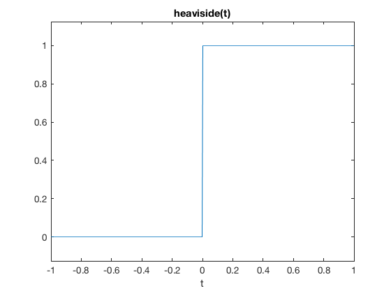

```matlab
syms t
ezplot(heaviside(t),[-1,1])
heaviside(0)
```

### Circuit Revisited

Consider the network shown below, where the switch is closed at time $t=T$.

[figure not shown]

Express the output voltage $v_{\mathrm{out}}$ as a function of the unit step function, and sketch the appropriate waveform.

## Simple Signal Operations

### Amplitude Scaling

Sketch $Au_0(t)$ and $-Au_0(t)$

### Time Reversal

Sketch $u_0(-t)$

### Time Delay and Advance

Sketch $u_0(t-T)$ and $u_0(t+T)$

## Examples

### Example 1

Which of these signals represents $-Au_0(t+T)$?

[figure not shown]

#### -> Open Poll

### Example 2

What is represented by

[figure not shown]

#### -> Open Poll

## Synthesis of Signals from Unit Step

Unit step functions can be used to represent other time-varying functions such as rectangular pulses, square waves and triangular pulses.

### Synthesize Rectangular Pulse

[figure not shown]

### Synthesize Square Wave

[figure not shown]

### Synthesize Symmetric Rectangular Pulse

[figure not shown]

### Synthesize Symmetric Triangular Pulse

[figure not shown]

## The Ramp Function

[figure not shown]

In the circuit shown above $i_s$ is a constant current source and the switch is closed at time $t=0$.

Show that the voltage across the capacitor can be represented as

$$v_C(t)=\frac{i_s}{C}t u_0(t)$$

and sketch the wave form.

The unit ramp function is defined as

$$u_1(t) = \int_{-\infty}^{t}u_0(\tau)d\tau$$

so

$${u_1}(t) = \left\{ {\begin{array}{*{20}{c}} {0\quad t < 0}\\ {t\quad t \ge 0} \end{array}} \right.$$

and

$$u_0(t) = \frac{d }{dt}u_1(t)$$

## The Dirac Delta Function

[figure not shown]

In the circuit shown above, the switch is closed at time $t=0$ and $i_L(t)=0$ for $t<0$. Express the inductor current $i_L(t)$ in terms of the unit step function and hence derive an expression for $v_L(t)$.

### The delta function

The unit impulse or the delta function, denoted as $\delta(t)$, is the derivative of the unit step.

This function is tricky because $u_0(t)$ is discontinuous at $t=0$ but it must have the properties

$$\int_{-\infty}^{t}\delta(\tau)d\tau = u_0(t)$$

and

$\delta(t) = 0$ for all $t\ne 0$.

### Sketch of the delta function

[figure not shown]

## Important properties of the delta function

### Sampling Property

The *sampling property* of the delta function states that

$$f(t)\delta(t-a) = f(a)\delta(t-a)$$

or, when $a = 0$,

$$f(t)\delta(t) = f(0)\delta(t)$$

### Sifting Property

The *sifting property* of the delta function states that

$$\int_{-\infty}^{\infty}f(t)\delta(t-\alpha)dt=f(\alpha)$$

### Higher Order Delta Fuctions

the n*th*-order *delta function* is defined as the n*th* derivative of $u_0(t)$, that is

$$\delta^n(t)=\frac{d^n}{dt^n}[u_0(t)]$$

The function $\delta'(t)$ is called the *doublet*, $\delta''(t)$ is called the *triplet* and so on.

By a procedure similar to the derivation of the sampling property we can show that

$$f(t)\delta'(t-a)=f(a)\delta'(t-a)-f'(t)\delta(t-a)$$

Also, derivation of the sifting property can be extended to show that

$$\int_{-\infty}^{\infty}f(t)\delta^n(t-\alpha)dt = {\left. {{{( - 1)}^n}\frac{{{d^n}}}{{d{t^n}}}[f(t)]} \right|_{t = \alpha }}$$

## Examples

### Example 3

Evaluate the following expressions

$$3t^4\delta(t-1) $$

$$\int_{-\infty}^{\infty}t\delta(t-2)dt$$

$$t^2\delta'(t-3)$$

### Example 4

[figure not shown]

(1) Express the voltage waveform $v(t)$ shown above as a sum of unit step functions for the time interval $-1 < t < 7$ s

Using the result of part (1), compute the derivative of $v(t)$ and sketch its waveform.

## Lab Work

In the second lab, a week on Monday, we will solve Example 2 using Matlab/Simulink following the procedure given between pages 1-17 and 1-22 of the textbook. We will also explore the `heaviside` and `dirac` functions.